# Spatial Transcriptomics - Xenium Analysis

# 6 Marker Analysis & Cell Type Annotation

We identify marker genes and annotate each cluster based on known cell types. This gives biological meaning to the clusters and helps define what kinds of cells are where in the tissue.

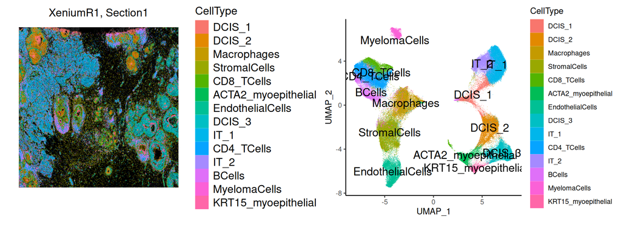

```r
# Convert to Seurat for marker detection
Xen_R1$Clusters <- Xen_R1_ondisk$Clusters
Xen_R1_seu <- VoltRon::as.Seurat(Xen_R1, cell.assay = "Xenium", type = "image")
Idents(Xen_R1_seu) <- "Clusters"
Xen_R1_seu <- NormalizeData(Xen_R1_seu, scale.factor = 1000)
markers <- FindAllMarkers(Xen_R1_seu)

# Annotate clusters with known labels
annotations <- read.table("../workshop/data/BreastCancer/Xenium_R1/annotation.txt")[,1]
CellType <- factor(Xen_R1_ondisk$Clusters)
levels(CellType) <- annotations
Xen_R1_ondisk$CellType <- as.character(CellType)

# Visualize annotations
p1 <- vrSpatialPlot(Xen_R1_ondisk, group.by = "CellType", pt.size = 0.18, alpha = 1)
p2 <- vrEmbeddingPlot(Xen_R1_ondisk, group.by = "CellType", embedding = "umap", pt.size = 0.4, label = TRUE)

# Save annotated object
Xen_R1_ondisk <- saveVoltRon(Xen_R1_ondisk)
(p1 | p2)
```

# 7 Spatially Aware Clustering (Niche Clustering)

Now that we know cell types, we want to see how they’re arranged in tissue. Using **spatial neighborhoods**, we build a graph of cell-cell proximity, compute the **abundance of cell types around each cell**, normalize them (CLR), and perform **k-means clustering**.

These **niche clusters** reveal **tissue microenvironments** — like immune zones or invasive tumor nests — based on **compositional cell-type context**.

[output not shown]

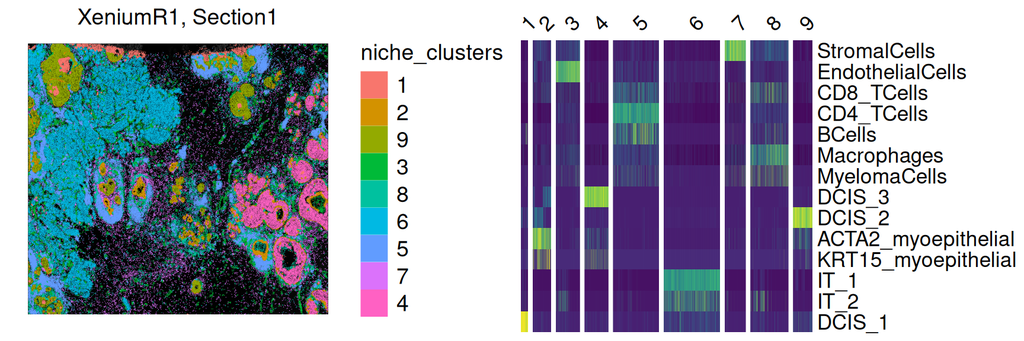

```r
# Build spatial neighbor graph
Xen_R1_ondisk <- getSpatialNeighbors(Xen_R1_ondisk, radius = 30, method = "radius")

# Build niche matrix
Xen_R1_ondisk <- getNicheAssay(Xen_R1_ondisk, label = "CellType", graph.type = "radius", overwrite =TRUE)

# Normalize + cluster niche profiles
vrMainFeatureType(Xen_R1_ondisk) <- "Niche"
Xen_R1_ondisk <- normalizeData(Xen_R1_ondisk, method = "CLR")
Xen_R1_ondisk <- getClusters(Xen_R1_ondisk, nclus = 9, method = "kmeans", label = "niche_clusters")

# Visualize
p1 <- vrSpatialPlot(Xen_R1_ondisk, group.by = "niche_clusters", alpha = 1)
p2 <- vrHeatmapPlot(Xen_R1_ondisk, features = vrFeatures(Xen_R1_ondisk), group.by = "niche_clusters")
(p1 | p2)
```

> 💬 *Interpretation:* In the clustering plots, different **niche clusters** represent distinct **spatial microenvironments**. For example: cluster 2 (**ACTA2 and KRT-positive epithelial cells**) suggest structural zones, while immune-dense niches cluster separately. These patterns help us map **functional domains** within the tissue, guided by **cellular composition and spatial context**.

# 8 Subsetting Cell Types

To explore **immune infiltration** or **stromal interactions**, we subset and visualize specific cell types. These plots help confirm findings from the niche heatmaps.

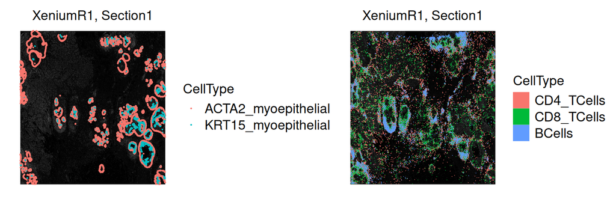

```r
p1 <- vrSpatialPlot(Xen_R1_ondisk, group.by = "CellType", pt.size = 0.18, alpha = 1,
              group.ids = c("ACTA2_myoepithelial", "KRT15_myoepithelial"))

p2 <- vrSpatialPlot(Xen_R1_ondisk, group.by = "CellType", pt.size = 1, alpha = 1,
              group.ids = c("CD4_TCells", "CD8_TCells", "BCells"), n.tile = 400)
(p1 | p2)
```

> 🔍 Interpretation of Spatial & Niche Clustering Plots
> - **ACTA2 / KRT15** myoepithelial cells form **structural boundaries**, likely marking tumor edges or ductal structures.
> - **CD4 / CD8 T cells and B cells** highlight areas of **immune infiltration**, with CD8+ T cells suggesting cytotoxic responses and B cells possibly forming lymphoid-like structures.

# 9 Hot Spot Analysis

This analysis detects **statistical hotspots** of a specific gene (e.g. `PGR`), identifying areas where expression is **significantly elevated in both a cell and its neighbors**.  
It uses **Getis-Ord statistics**, comparing local vs. global expression means, and outputs per-cell p-values.

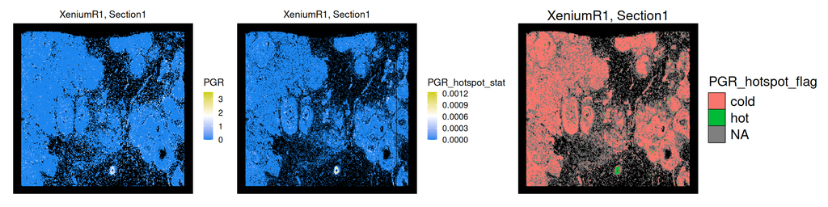

```r
# Build spatial neighbor graph for hotspot
Xen_R1_ondisk <- getSpatialNeighbors(Xen_R1_ondisk, method = "radius", radius = 15, graph.key = "radius_hot")

# Define RNA features as main
vrMainFeatureType(Xen_R1_ondisk) <- "RNA"

# Visualize gene
p1 <- vrSpatialFeaturePlot(Xen_R1_ondisk, features = "PGR", alpha = 1, background.color = "black", n.tile = 300)

# Run hotspot test
Xen_R1_ondisk <- getHotSpotAnalysis(Xen_R1_ondisk, features = "PGR", graph.type = "radius_hot", alpha.value = 0.001)

# Visualize significant regions
p2 <- vrSpatialFeaturePlot(Xen_R1_ondisk, features = "PGR_hotspot_stat", alpha = 1, background.color = "black", n.tile = 400)
p3 <- vrSpatialPlot(Xen_R1_ondisk, group.by = "PGR_hotspot_flag", alpha = 1, background.color = "black", n.tile = 400)

p1 + p2 + p3
```

> 💬 *Explanation:* Hotspot analysis pinpoints **regions of biological activity**, such as hormone-active tumor zones or interferon responses. It complements clustering by analyzing **spatial patterns of single gene features**.

# 10 Summary

This Xenium pipeline provides a high-resolution, cell-level spatial analysis of breast cancer tissue, including:

- Cell identity classification
- Microenvironment niche clustering
- Detection of spatial gene expression hotspots

These steps help us understand **cellular organization, interactions, and functional zones** — essential for cancer biology, immunology, and tissue profiling.

# 11 Environment & Dataset Setup

## 11.1 Run RStudio in Docker

Use a pre-built Docker image with VoltRon and all dependencies pre-installed.

1. Make sure [Docker Desktop](https://www.docker.com/products/docker-desktop) is installed.
2. Pull the image:

```bash
docker pull amanukyan1385/rstudio-voltron:main
```

3. Start the container:

```bash
docker run --rm -ti \
  -e PASSWORD=yourpassword \
  -p 8787:8787 \
  -v Path/to/your/dataset:/home/rstudio/project \
  amanukyan1385/rstudio-voltron:main
```

4. Access RStudio:  
   http://localhost:8787
   - Username: `rstudio`
   - Password: `yourpassword` # you can change your own password

You can also use Docker Desktop GUI if you prefer volume mounting.

## 11.2 Datasets

Download the complete dataset bundle used in this notebook:

**Download all datasets (ZIP)** **- including datasets for other markdown**

### 11.2.1 Original Dataset Sources

- **Xenium – Breast Cancer**
  - [Preview Dataset](https://www.10xgenomics.com/products/xenium-in-situ/preview-dataset-human-breast)